# TATA variants

Jeremy Primus and Kevin Morey

1/23/2018

## Introduction

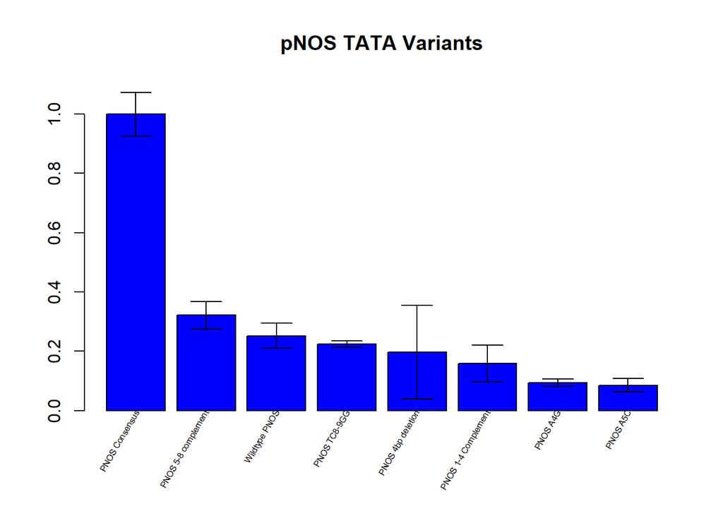

```r
# Data input

# quantified and normalized in Matlab
relativeLuminescence <- c(1, 0.321591, 0.251972, 0.224204, 0.197042,0.158389, 0.0938343, 0.0848641)
stderror <- c(0.1472, 0.0919, 0.0861, 0.0226, 0.3152, 0.1229, 0.0244, 0.0448)
promoterNames <- c("PNOS Consensus", "PNOS 5-8 complement", "Wildtype PNOS", "PNOS TC8-9GG", "PNOS 4bp deletion", "PNOS 1-4 Complement", "PNOS A4G","PNOS A5C")
sequence <- c('TATATATAC', 'CATATTAAC', 'CATAAATTC', 'CATAAATGG', 'GTTAAATTC','GTATAATTC', 'GTATAATTC', 'CATACATTC')

# from Mathematica Solve
analyticalDelG <- c(0, 1.65232, 1.93693, 2.06945, 2.21377, 2.45334, 3.01132, 3.11649) # change in equilibrium binding constant

# Bar plot of relative luminesence
mids <- barplot(relativeLuminescence, main="pNOS TATA Variants", ylim = c(0, 1.1), col = "blue")
text(x = mids, y = 0, srt = 60, adj = 1, labels = promoterNames, cex = 0.5, xpd = TRUE)
# add error bars
arrows(x0 = mids, y0 = relativeLuminescence - stderror/2, x1 = mids, y1 = relativeLuminescence + stderror/2, code = 3, angle = 90, length = 0.15 )
```

## Analysis

```
 Assuming the measured luminescence is proportional to the transcription rate, we can approximate the effect of the nucleotide edits on the equilibrium binding constant, $K_{eq}$
```

## Thermodynamically Modeling Transcription Rates

Define all energies relative to a ground state: $\Delta G$  
The TATA binding protein/promoter interaction has two possible states: unbound, and bound  
The unbound state is the same energetically for all promoter variants, so we choose this to be the ground state: 0

For the *i*-th variant, the binding interaction energy, measured relative to the unoccupied state, 0 is $\Delta G_{i}$

The partition function describes the statistical properties of a system in thermodynamic equilibrium.

$$P(b) = \frac{e^{-\Delta G_{i}}}{1+e^{-\Delta G_{i}}}$$
Assuming transcription rate $TR_i$ is proportional to binding probability
$$TR_{i} = \alpha \frac{e^{-\Delta G_{i}}}{1+e^{-\Delta G_{i}}} + \epsilon$$
where $\alpha$ and $\epsilon$ are the theoretical maximum and minumum transcription rates - (explain behavior of the function?)

Assume measured luminescence to be proportional to $TR_{i}$
so
$$L_i = A\left [\alpha \frac{e^{-\Delta G_{i}}}{1+e^{-\Delta G_{i}}} + \epsilon \right] = \widetilde{\alpha} \frac{e^{-\Delta G_{i}}}{1+e^{-\Delta G_{i}}} + \widetilde{\epsilon}$$

[figure not shown]

```r
library(DEoptim)

# Bar plot of luminesence
data <- relativeLuminescence

# function to be minimized
#fitVars <- c(a, e, Go, delG2, delG3, delG4, delG5, delG6, delG7, delG8)
minFcn <- function(fitVars) {
  f <-(fitVars[1]*exp(-fitVars[3])/(1+exp(-fitVars[3]))+fitVars[2] - data[1])^2 + sum((fitVars[1]*exp(-fitVars[3]-fitVars[3:10])/(1+exp(-fitVars[3]-fitVars[3:10])) - data[1:8])^2)
}

lower <- rep(0,10)                              # set bounds for fit algorithm
upper <- rep(15,10)
set.seed(1234)                                  # set seed for reproducibility
outDEoptim <- DEoptim(minFcn, lower, upper)     # run fit
paramFits <- outDEoptim$optim$bestmem

#summary(outDEoptim)
# assign fit parameters
alpha <- paramFits[1]
epsilon <- paramFits[2]
Go <- paramFits[3]
delG<- paramFits[4:10]
x = c(Go, Go+delG)
y <- alpha*exp(-Go-delG)/(1+exp(-Go-delG)) + epsilon
hy <- alpha*exp(-Go)/(1+exp(-Go)) + epsilon
```

**Table 1.** Binding energy values ($E/k_{B}T$) obtained from thermodynamic fits. Values are relative to consensus.

|  | Variant | Sequence | Delta G (fit) | Delta G (analytical) |
| --- | --- | --- | --- | --- |
|  | PNOS Consensus | TATATATAC | 0.000000 | 0.00000 |
| par4 | PNOS 5-8 complement | CATATTAAC | 1.634346 | 1.65232 |
| par5 | Wildtype PNOS | CATAAATTC | 1.845735 | 1.93693 |
| par6 | PNOS TC8-9GG | CATAAATGG | 2.094041 | 2.06945 |
| par7 | PNOS 4bp deletion | GTTAAATTC | 2.105524 | 2.21377 |
| par8 | PNOS 1-4 Complement | GTATAATTC | 2.383086 | 2.45334 |
| par9 | PNOS A4G | GTATAATTC | 2.967135 | 3.01132 |
| par10 | PNOS A5C | CATACATTC | 3.116791 | 3.11649 |